# Programming Languages Popularity

- The main goal of this project is to analyze the general attitude towards programming languages, compared to their relevance. The data was collected from social networks, more specifically Reddit, since it's a good environment for discussing a great range of subjects - including programming topics;
- Instead of focusing on trainning a model and creating a optimized algorithm, I aimed for a clear sharing and visualization of the analysis made;
- Observations:
  - For the code to work, it is necessary for whoever is running this code to insert their Reddit API keys;
  - I used my credentials through a separated file.

## Imports and Prep

```python
import pandas as pd
import numpy as np
import praw
import json
import matplotlib.pyplot as plt
import nltk
from transformers import AutoTokenizer
from transformers import AutoModelForSequenceClassification
from scipy.special import softmax
import torch
```

### User's Tokens

The user keys must be inserted on their respective variable.

- Personal use script code
  - client_id=''
- Secret key
  - client_secret=''
- App name
  - user_agent=''
- Reddit username and password
  - username=''
  - password=''

```python
with open('user_credentials.json') as file:
   user_credentials = json.load(file)
```

```python
reddit=praw.Reddit(client_id=user_credentials['client_id'],
                   client_secret=user_credentials['client_secret'],
                   user_agent=user_credentials['user_agent'],
                   username=user_credentials['username'],
                   password=user_credentials['password'])
```

## Gathering and Pre-Processing

#### Creating a generic function to get the trending submissions, its comments and the number of subscribers of the given Subreddit

```python
def get_subreddit_topics(topic: str):
    subred = reddit.subreddit(topic)
    hot_subs = list(subred.hot(limit=100))

    result_array = []
    comments=[]
    for submission in hot_subs:
        result_array.append([submission.title,submission.selftext])
        submission.comments.replace_more(limit=None)

        for comment in submission.comments.list():
            comments.append(comment.body)

    num_subscribers = subred.subscribers
    return result_array, comments, num_subscribers
```

#### Lists for storing the data

```python
subreddits=['java', 'Python', 'C_Programming', 'cobol']
#Java
java_data=[]
java_comments=[]
java_subscribers=0
#Python
python_data=[]
python_comments=[]
python_subscribers=0
#C-lang
c_data=[]
c_comments=[]
c_subscribers=0
#COBOL
cobol_data=[]
cobol_comments=[]
cobol_subscribers=0

#Lists grouping the data/ the comments and the total subscribers of each language
lang_data=[java_data,
python_data,
c_data,
cobol_data]

lang_comments=[
    java_comments,
    python_comments,
    c_comments,
    cobol_comments
]

lang_subscribers=[
    java_subscribers,
    python_subscribers,
    c_subscribers,
    cobol_subscribers
]
```

#### Creating a loop to streamline the process of data entry

```python
for i in range(0,4):
    lang_data[i], lang_comments[i], lang_subscribers[i]=get_subreddit_topics(subreddits[i])
    #printing 'running' to see if the loop is working fine
    print('running')
```

```
running
running
running
running
```

#### Creating the DataFrames

```python
Java_comments=pd.DataFrame(lang_comments[0])
Python_comments=pd.DataFrame(lang_comments[1])
C_comments=pd.DataFrame(lang_comments[2])
Cobol_comments=pd.DataFrame(lang_comments[3])
```

All of these DataFrames contain a single column (named '0') which holds all the comments. To enhance visualization and understanding on the next steps, I will rename these columns.

```python
Java_comments.rename(columns={0:'Comments'}, inplace=True)
Python_comments.rename(columns={0:'Comments'}, inplace=True)
C_comments.rename(columns={0:'Comments'}, inplace=True)
Cobol_comments.rename(columns={0:'Comments'}, inplace=True)
```

Checking if it worked.

```python
Java_comments.head()
```

|  | Comments |
| --- | --- |
| 0 | On July 1st, a [change to Reddit's API pricing... |
| 1 | Cool, just seems weird that this wasn't the fi... |
| 2 | On July 1st, a [change to Reddit's API pricing... |
| 3 | On July 1st, a [change to Reddit's API pricing... |
| 4 | If you want to work in the industry, they will... |

Now creating the dataframe with subscribers info and doing the same work on the names.

```python
Subscribers_df=pd.DataFrame(lang_subscribers)
Subscribers_df.head()
```

|  | 0 |
| --- | --- |
| 0 | 301160 |
| 1 | 1148755 |
| 2 | 144366 |
| 3 | 3355 |

```python
Subscribers_df.rename(columns={0:'Number_of_subscribers'}, inplace=True)
Subscribers_df.rename(index={0:'Java', 1:'Python',2:'C',3:'COBOL'}, inplace=True)
Subscribers_df.head()
```

|  | Number_of_subscribers |
| --- | --- |
| Java | 301160 |
| Python | 1148755 |
| C | 144366 |
| COBOL | 3355 |

The differences between the number of subscribers show us a general idea of the popularity of each language. Plotting a bar graph to simplify visualization and understanding:

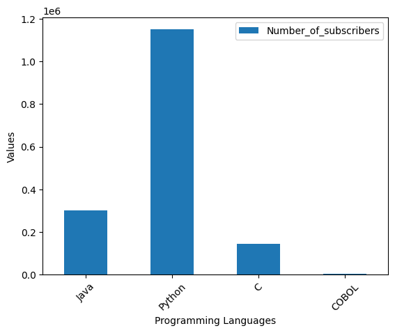

```python
ax=Subscribers_df.plot.bar(rot=45)
ax.set_xlabel('Programming Languages')
ax.set_ylabel('Values')
plt.show()
```

Finally, creating the submissions' dataframe and renaming their labels.

```python
Java_subm=pd.DataFrame(lang_data[0])
Python_subm=pd.DataFrame(lang_data[1])
C_subm=pd.DataFrame(lang_data[2])
Cobol_subm=pd.DataFrame(lang_data[3])
```

```python
Java_subm.rename(columns={0:'Title',1:'Text'},inplace=True)
Python_subm.rename(columns={0:'Title',1:'Text'},inplace=True)
C_subm.rename(columns={0:'Title',1:'Text'},inplace=True)
Cobol_subm.rename(columns={0:'Title',1:'Text'},inplace=True)
```

Dropping the rows with no text

```python
Java_subm['Text'].replace('', np.nan, inplace=True)
Python_subm['Text'].replace('', np.nan, inplace=True)
C_subm['Text'].replace('', np.nan, inplace=True)
Cobol_subm['Text'].replace('', np.nan, inplace=True)
```

```python
Java_subm.head()
```

|  | Title | Text |
| --- | --- | --- |
| 0 | [PSA]/r/java is not for programming help, lear... | # /r/java is not for programming help or learn... |
| 1 | JVMLS 2023 keynote (Georges Saab & Mark Reinhold) | NaN |
| 2 | SpringOne Tour Amsterdam | For those based in The Netherlands working wit... |
| 3 | Should I use Servlets and JSP? | I am assigned a minor project in my college. I... |
| 4 | Need help with Code Organaziation! | I'm currently trying to make Library Managemen... |

```python
Java_subm.dropna(subset=['Text'], inplace=True)
Python_subm.dropna(subset=['Text'], inplace=True)
C_subm.dropna(subset=['Text'], inplace=True)
Cobol_subm.dropna(subset=['Text'], inplace=True)
```

```python
Java_subm.head()
```

|  | Title | Text |
| --- | --- | --- |
| 0 | [PSA]/r/java is not for programming help, lear... | # /r/java is not for programming help or learn... |
| 2 | SpringOne Tour Amsterdam | For those based in The Netherlands working wit... |
| 3 | Should I use Servlets and JSP? | I am assigned a minor project in my college. I... |
| 4 | Need help with Code Organaziation! | I'm currently trying to make Library Managemen... |
| 6 | why would i ever use a microservice.... | if i could do a highly efficient one-line fun... |

## Sentiment Analysis using RoBERTa Pre-Trained Model

```python
MODEL = f"cardiffnlp/twitter-roberta-base-sentiment-latest"
tokenizer = AutoTokenizer.from_pretrained(MODEL)
model = AutoModelForSequenceClassification.from_pretrained(MODEL)
```

[output not shown]

```python
def determine_sentiment(text):
    max_seq_length = 128
    encoded_text = tokenizer(text, return_tensors='pt', padding='max_length', truncation=True, max_length=max_seq_length)
    output = model(**encoded_text)
    scores = output[0][0].detach().numpy()
    scores = softmax(scores)

    # Comparing the values and returning the index of the biggest one
    scores_labels = ['negative', 'neutral', 'positive']
    max_value_index = np.argmax(scores)

    scores_dict = {
        'label': scores_labels[max_value_index],
        'value': scores[max_value_index]
    }

    return scores_dict
```

### Applying the function to the dataframes

Individualizing the process to avoid any tensor errors.

#### First for the submissions

```python
#Java
Java_subm['Text_Sentiment'] = Java_subm['Text'].apply(determine_sentiment)
#Python
Python_subm['Text_Sentiment'] = Python_subm['Text'].apply(determine_sentiment)
#C
C_subm['Text_Sentiment'] = C_subm['Text'].apply(determine_sentiment)
#Cobol
Cobol_subm['Text_Sentiment'] = Cobol_subm['Text'].apply(determine_sentiment)
```

```python
Java_subm.head()
```

|  | Title | Text | Text_Sentiment |
| --- | --- | --- | --- |
| 0 | [PSA]/r/java is not for programming help, lear... | # /r/java is not for programming help or learn... | {'label': 'negative', 'value': 0.71142405} |
| 2 | SpringOne Tour Amsterdam | For those based in The Netherlands working wit... | {'label': 'neutral', 'value': 0.6981339} |
| 3 | Should I use Servlets and JSP? | I am assigned a minor project in my college. I... | {'label': 'neutral', 'value': 0.8999877} |
| 4 | Need help with Code Organaziation! | I'm currently trying to make Library Managemen... | {'label': 'negative', 'value': 0.49277163} |
| 6 | why would i ever use a microservice.... | if i could do a highly efficient one-line fun... | {'label': 'negative', 'value': 0.5953579} |

#### Now for the comments

```python
#Java
Java_comments['Comments_Sentiment'] = Java_comments['Comments'].apply(determine_sentiment)
#Python
Python_comments['Comments_Sentiment'] = Python_comments['Comments'].apply(determine_sentiment)
#C
C_comments['Comments_Sentiment'] = C_comments['Comments'].apply(determine_sentiment)
#Cobol
Cobol_comments['Comments_Sentiment'] = Cobol_comments['Comments'].apply(determine_sentiment)
```

```python
Java_comments.head()
```

|  | Comments | Comments_Sentiment |
| --- | --- | --- |
| 0 | On July 1st, a [change to Reddit's API pricing... | {'label': 'neutral', 'value': 0.853849} |
| 1 | Cool, just seems weird that this wasn't the fi... | {'label': 'neutral', 'value': 0.73229575} |
| 2 | On July 1st, a [change to Reddit's API pricing... | {'label': 'neutral', 'value': 0.853849} |
| 3 | On July 1st, a [change to Reddit's API pricing... | {'label': 'neutral', 'value': 0.853849} |
| 4 | If you want to work in the industry, they will... | {'label': 'neutral', 'value': 0.5717754} |

### Counting the appearance of labels for each language

Where language_count=[number of negatives, number of neutral, number of positives]

```python
java_count=[]
python_count=[]
c_count=[]
cobol_count=[]

#List containing the count lists
count = [java_count,
python_count,
c_count,
cobol_count]

scores_labels = ['negative', 'neutral', 'positive']

#List of comment dataframes
commentdataframes=[Java_comments, Python_comments, C_comments, Cobol_comments]
submissiondataframes=[Java_subm, Python_subm, C_subm, Cobol_subm]
```

```python
for i in range(4):
    for label in scores_labels:
        comment_sum=commentdataframes[i].Comments_Sentiment.apply(lambda df: df['label'] == label).sum()
        submission_sum=submissiondataframes[i].Text_Sentiment.apply(lambda df: df['label'] == label).sum()
        count[i].append(comment_sum+submission_sum)
```

## Visualizing the information

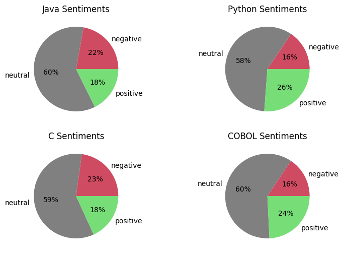

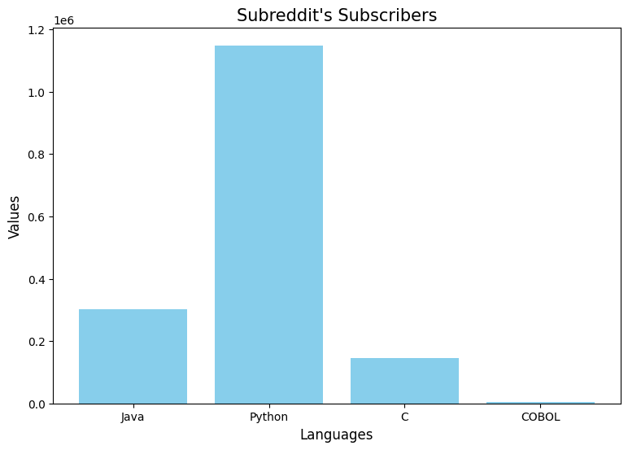

```python
fig, axes=plt.subplots(2,2, figsize=(9,6))
slices_java = [java_count[0], java_count[1], java_count[2]]
slices_python = [python_count[0], python_count[1], python_count[2]]
slices_c = [c_count[0], c_count[1], c_count[2]]
slices_cobol = [cobol_count[0], cobol_count[1], cobol_count[2]]


axes[0][0].pie(slices_java, labels=scores_labels, autopct='%.0f%%', colors=['#CF4B61', 'grey','#77dd77'])
axes[0][0].set_title('Java Sentiments')

axes[0][1].pie(slices_python, labels=scores_labels, autopct='%.0f%%', colors=['#CF4B61', 'grey','#77dd77'])
axes[0][1].set_title('Python Sentiments')

axes[1][0].pie(slices_c, labels=scores_labels, autopct='%.0f%%', colors=['#CF4B61', 'grey','#77dd77'])
axes[1][0].set_title('C Sentiments')

axes[1][1].pie(slices_cobol, labels=scores_labels,autopct='%.0f%%', colors=['#CF4B61', 'grey','#77dd77'])
axes[1][1].set_title('COBOL Sentiments')

common_legend=plt.legend
plt.show()

plt.figure(figsize=(9,6))

ax = plt.bar(Subscribers_df.index, Subscribers_df['Number_of_subscribers'], color='skyblue')
plt.title("Subreddit's Subscribers",fontsize=15)
plt.xlabel('Languages',fontsize=12)
plt.ylabel('Values',fontsize=12)
plt.show()
```